# Handout W04 — Porównania grup i zależności kategorii

Zarządzanie informacją — mapa projektu, efektu i testu — 2026/27

Marek Deja

2026/27

# Najpierw ustal strukturę

Projekty porównania

| Projekt | Wielkość główna | Kluczowa kontrola |
| --- | --- | --- |
| Dwie niezależne grupy, wynik ilościowy | Różnica średnich | Różne osoby, N i SD w obu grupach |
| Dwa pomiary tych samych osób | Średnia różnica wewnątrz par | Identyfikator i kompletne pary |
| Dwie zmienne kategorialne | Proporcje i związek w tabeli | Liczebności, mianowniki, liczebności oczekiwane |
| Więcej grup | Zaplanowany kontrast lub test ogólny | Kontrola wielokrotności i właściwy model |
| Wynik interpretowany rangowo | Estymanda θ | Pytanie o porządek wyników |

Parę tworzy ta sama osoba. Zadania jednej osoby tworzą obserwacje zależne. Grupy obserwacyjne zachowują swój charakter przy każdej metodzie testu, także przy teście permutacyjnym.

# Jeden kierunek we wszystkich wynikach

$$\Delta=\mu_N-\mu_D,\qquad
\widehat\Delta=\bar{x}_N-\bar{x}_D.$$

Kierunek nowi minus doświadczeni: dodatni wynik czasu oznacza dłuższy czas nowych, dodatni indeks — wyższą deklarację w kierunku skali. Odwrócenie kolejności zmienia znak różnicy, t, g i granic przedziału: [L; U] przechodzi w [−U; −L]; dwustronne p pozostaje takie samo.

# Welch: obie średnie mają niepewność

$$SE=\sqrt{\frac{s_N^2}{n_N}+\frac{s_D^2}{n_D}},
\quad t_W=\frac{\widehat\Delta}{SE},
\quad CI_{95\%}=\widehat\Delta\pm t_{0{,}975;\,\nu}\,SE.$$

Test Welcha dopuszcza różne wariancje grup i wymaga właściwego projektu oraz uzasadnienia przybliżenia. Stopnie swobody $\nu$ są zwykle liczbą niecałkowitą, wynikiem przybliżenia Welcha–Satterthwaite’a. Rozkład oceniają wykres kwantylowy i histogram, a niezależność — projekt.

Przykład hipotetyczny: po 5 osób, średnie czasu 12 i 8 minut, SD w obu grupach 3,16. Różnica wynosi 4 minuty, SE = 2, t(8) = 2, p = 0,081, 95% CI [−0,61; 8,61] minuty: dodatnia estymata z dużą niepewnością. Test permutacyjny ze wszystkimi 252 podziałami etykiet daje p = 32/252 = 0,127.

$$s_p=\sqrt{\frac{(n_N-1)s_N^2+(n_D-1)s_D^2}{n_N+n_D-2}},
\quad
g\approx\left(1-\frac{3}{4(n_N+n_D)-9}\right)
\frac{\widehat\Delta}{s_p}=1{,}14 .$$

Mianownikiem $g$ jest rozrzut osób, a mianownikiem $t_W$ — SE różnicy. Naturalna różnica w minutach lub punktach pozostaje podstawą sensu praktycznego; duże $g$ i p powyżej 0,05 współwystępują przy małej próbie.

# Pary: jedna różnica na osobę

$$d_i=x_{i,\mathrm{po}}-x_{i,\mathrm{przed}},
\quad t=\frac{\bar d}{s_d/\sqrt{n_{\mathrm{par}}}},
\quad df=n_{\mathrm{par}}-1.$$

Ujemna zmiana czasu oznacza skrócenie. Warunek normalności dotyczy rozkładu różnic. W przykładzie sześciu osób zmiana wynosi −2,17 minuty, 95% CI [−3,39; −0,94], t(5) = −4,54, p = 0,0062; zmiana łączy działanie instruktażu, zapamiętanie zadania i oswojenie z procedurą.

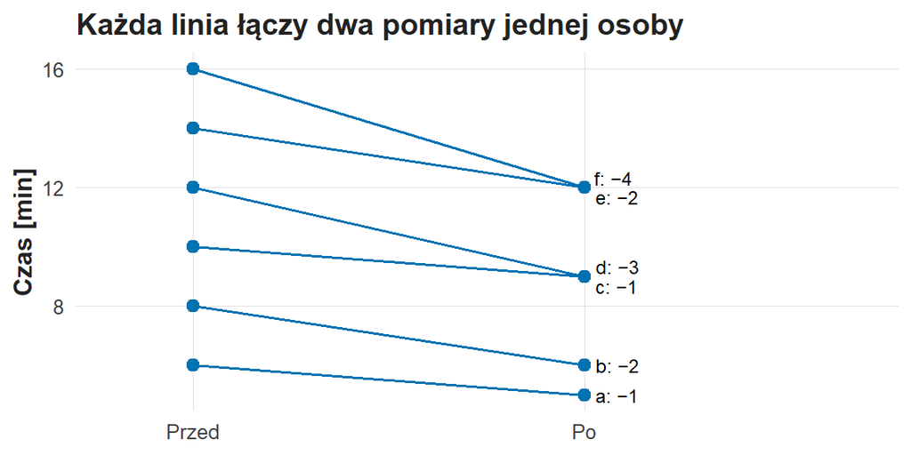

Każda linia łączy dwa pomiary jednej osoby. Oś pozioma: pomiar przed i po; oś pionowa: czas w minutach. Sześć odcinków a–f; wszystkie opadają, o 1 do 4 minut.

# Test permutacyjny i bootstrap zachowują projekt

Test permutacyjny dwóch grup przestawia etykiety przy zachowaniu liczebności, gdy przy $H_0$ uzasadniona jest wymienialność: każdy podział etykiet jest równie prawdopodobny. Przy różnych rozkładach grup statystyka $t_W$ jako miara skrajności zachowuje poziom α w przybliżeniu.

Bootstrap dwóch grup losuje z powtórzeniami osobno w każdej grupie i szacuje niepewność różnicy. Dla par losuje się całe pary. Test zmian znaków różnic par zakłada symetrię lub randomizację: sześć par daje 64 układy znaków, a najmniejsze osiągalne p wynosi 2/64 = 0,031.

# Kategorie: od komórki do statystyki

$$E_{ij}=\frac{n_{i\cdot}\,n_{\cdot j}}N,\qquad
\chi^2=\sum_{i,j}\frac{(O_{ij}-E_{ij})^2}{E_{ij}},
\qquad df=(r-1)(c-1).$$

$O$ to liczebność obserwowana, $E$ — oczekiwana przy niezależności; $E$ może być ułamkiem. Test przyjmuje liczebności. Przybliżenie $\chi^2$ wymaga oczekiwanych liczebności co najmniej 5; przy mniejszych stosuje się test Fishera albo Monte Carlo z jawnym opisem procedury.

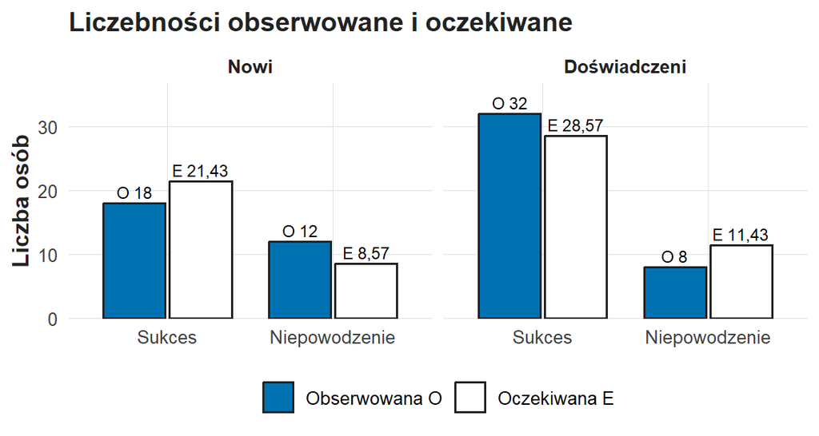

Liczebności obserwowane i oczekiwane w tabeli 18/30 i 32/40. Nowi: O 18 wobec E 21,43 sukcesu i O 12 wobec E 8,57 niepowodzenia. Doświadczeni: O 32 wobec E 28,57 i O 8 wobec E 11,43.

Rozkład $\chi^2_{df}$ to rozkład sumy kwadratów $df$ niezależnych zmiennych $Z$; wartość krytyczna dla df = 1 wynosi $3{,}84=1{,}96^2$. W przykładzie $\chi^2(1)=3{,}36$ i p = 0,067; Monte Carlo z zachowanymi marginesami daje p = 0,108, a test Fishera — p = 0,108.

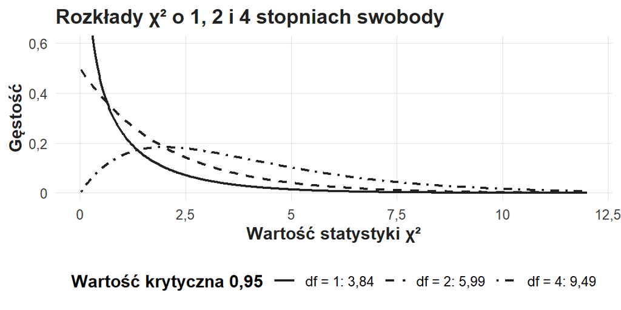

Rozkłady χ² o 1, 2 i 4 stopniach swobody. Wszystkie krzywe mają prawy ogon; wartości krytyczne 0,95 wynoszą 3,84; 5,99 i 9,49.

# Wielkość związku i wartość p

$$V=\sqrt{\frac{\chi^2}{N\min(r-1,c-1)}}=0{,}219 .$$

V opisuje siłę związku od 0 do 1; kierunek podaje różnica proporcji. Percentylowy przedział bootstrapowy V ma dodatnią dolną granicę także przy niezależności w populacji, więc związek testuje się testem $\chi^2$, Fishera lub Monte Carlo.

Trzy miary efektu tabeli 18/30 i 32/40

| Miara: nowi względem doświadczonych | Wynik | Odczyt |
| --- | --- | --- |
| Różnica proporcji | −0,20 | 20 punktów procentowych mniej |
| Iloraz proporcji RR | 0,75 | Odsetek nowych to 75% odsetka doświadczonych |
| Iloraz szans OR | 0,375 | Szansa 1,5 wobec 4: sukcesy do niepowodzeń |

Każdy przedział ma nazwę miary. Wartością braku różnicy jest 0 dla różnicy proporcji i 1 dla ilorazów.

# Rangi i wiele grup

Test Manna–Whitneya sprawdza hipotezę θ = 0,5, gdzie θ to prawdopodobieństwo, że losowa osoba z jednej grupy ma wyższy wynik od losowej osoby z drugiej (z połową remisów); w przykładzie czasu θ = 0,82. Odczyt jako przesunięcia mediany wymaga rozkładów o tym samym kształcie.

ANOVA sprawdza równość wszystkich średnich; wskazanie pary wymaga kontrastów lub porównań par z kontrolą wielokrotności. W przykładzie trzech grup F(2, 6) = 3,5, p = 0,098, $\eta^2=0{,}538$.

Raport podaje projekt, grupy, N, wielkość i kierunek efektu, jednostkę, przedział, statystykę, df, p i ograniczenie. Wniosek o przyczynie wymaga uzasadnienia projektu.

Definicje efektów: [Lakens (2013)](https://doi.org/10.3389/fpsyg.2013.00863). Warunki przestawień: [Winkler i in. (2014)](https://pmc.ncbi.nlm.nih.gov/articles/PMC4010955/).